# The Price of Weather

Sampson Wescoatt

12/17/2020

## Synopsis

Storms and other severe weather events can cause both public health and economic problems for communities and municipalities. Many severe events can result in fatalities, injuries, and property damage, and preventing such outcomes to the extent possible is a key concern.

This project involves exploring the U.S. National Oceanic and Atmospheric Administration’s (NOAA) storm database. This database tracks characteristics of major storms and weather events in the United States, including when and where they occur, as well as estimates of any fatalities, injuries, and property damage.

## Data Processing

Data for this assignment is provided in .bz2 compressed file format, so I used the read.csv() function to extract the data and load it into memory as a tibble using the dplyr library for effective data manipulation.

```r
## The dplyr library in tidyverse provides simple, effective data processing.
library(dplyr)

## The read.csv() function can take .bz2 files directly.
sdata <- as_tibble(read.csv("./repdata_data_StormData.csv.bz2"))
```

**Across the United States, which types of events are the most harmful with respect to population health?**

To evaluate this question, I grouped the raw data by event type and counted the fatalities and injuries to rank the total impact to human life caused by each event.

```r
library(tidyr)

fatal_data <- sdata %>%

  ## Select the appropriate metrics
  select(EVTYPE, FATALITIES, INJURIES) %>%

  ## Group by event
  group_by(event = EVTYPE) %>%

  ## Produce summary of harm
  summarize(
    fatalities = sum(FATALITIES, na.rm = TRUE),
    injuries = sum(INJURIES, na.rm = TRUE),
    total = fatalities + injuries) %>%

  ## Categorize totals by type
  pivot_longer(cols = c("fatalities", "injuries"),
               names_to = "type", values_to = "count") %>%

  ## Sort by most total fatalities + injuries
  arrange(desc(total)) %>%

  ## Select the top 15 events (x2 rows per event)
  head(30)
```

**Across the United States, which types of events have the greatest economic consequences?**

To answer this question, I grouped the raw data by event type once more, and summarized the property and crop damage to determine total cost of each event. The cost notation is stored in separate columns for base number and exponent(K for thousands, M for millions, etc.) and required a transformation to find the actual value, performed through nested conditional tests.

```r
econ_dmg <- sdata %>%

  ## Select the appropriate metrics
  select(EVTYPE, PROPDMG, PROPDMGEXP, CROPDMG, CROPDMGEXP) %>%

  ## Multiply base by exponent
  mutate(prop_total = ifelse(PROPDMGEXP == "B", PROPDMG * 1000000000,
                          ifelse(PROPDMGEXP == "M", PROPDMG * 1000000,
                              ifelse(PROPDMGEXP == "K", PROPDMG * 1000,
                                     PROPDMG)))) %>%

  ## Perform the same conversion for crop damage
  mutate(crop_total = ifelse(CROPDMGEXP == "B", CROPDMG * 1000000000,
                          ifelse(CROPDMGEXP == "M", CROPDMG * 1000000,
                              ifelse(CROPDMGEXP == "K", CROPDMG * 1000,
                                     CROPDMG)))) %>%

  ## Group by event type
  group_by(event = EVTYPE) %>%

  ## Summarize by total damage
  summarize(prop_dmg = sum(prop_total, na.rm = TRUE),
            crop_dmg = sum(crop_total, na.rm = TRUE),
            dmg_total = prop_dmg + crop_dmg) %>%

  ## Categorize totals by type
  pivot_longer(cols = c("prop_dmg", "crop_dmg"),
               names_to = "type", values_to = "cost") %>%

  ## Sort by highest cost
  arrange(desc(dmg_total)) %>%

  ## Select the top 15 (x2 rows per event)
  head(30)
```

## Results

The plot below shows the top 15 most harmful events to population health on record, determined by the total fatalities and injuries. Clearly, Tornadoes have had a more significant impact on human life by a large margin.

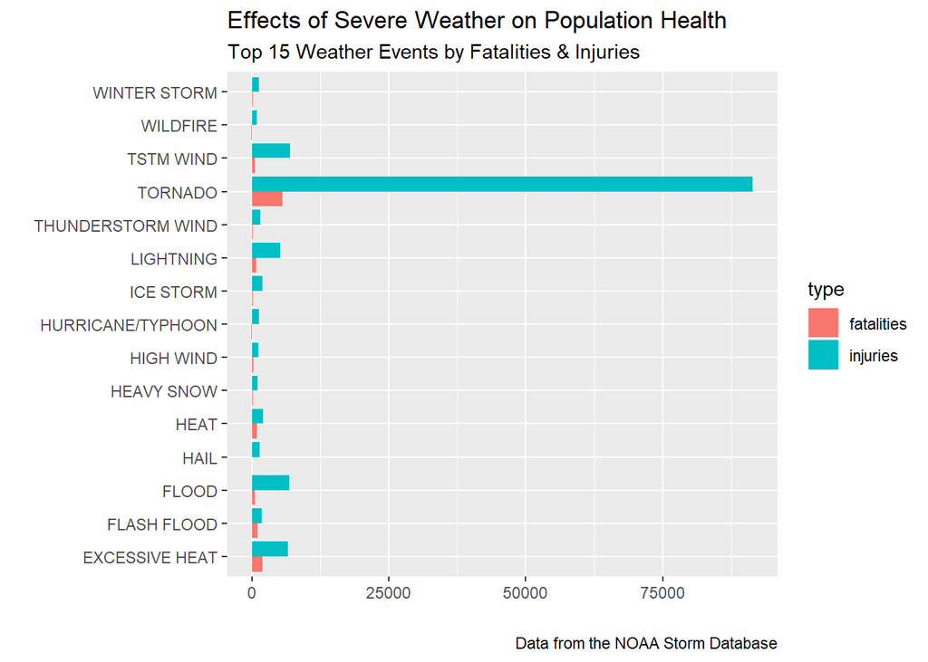

```r
library(ggplot2)

fatal_plot <- ggplot(fatal_data, aes(count, event, fill = type)) +
  geom_bar(stat = "identity", position = position_dodge()) +
  labs(title = "Effects of Severe Weather on Population Health",
       subtitle = "Top 15 Weather Events by Fatalities & Injuries",
       caption = "Data from the NOAA Storm Database",
       x = "",
       y = "")

print(fatal_plot)
```

The second plot shows the top 15 most economically harmful event types on record, as determined by the total cost in property and crop damage. Clearly, floods have lead in damage to property damage, with hurricanes and tornadoes following in second and third, respectively. Notably, droughts produce the highest crop damage.

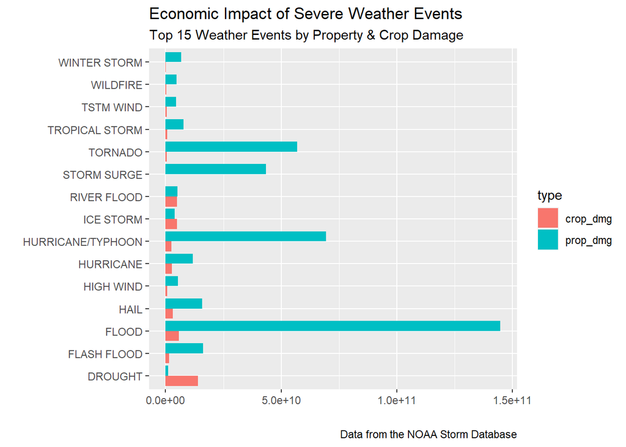

```r
econ_plot <- ggplot(econ_dmg, aes(cost, event, fill = type)) +
  geom_bar(stat = "identity", position = position_dodge()) +
  labs(title = "Economic Impact of Severe Weather Events",
       subtitle = "Top 15 Weather Events by Property & Crop Damage",
       caption = "Data from the NOAA Storm Database",
       x = "",
       y = "")

print(econ_plot)
```